# Normal probabilities and quantiles

This program displays the standard normal curve along with various probabilities and quantiles. It was written by Steve Simon on 2024-09-01 and is placed in the public domain.

## Load the tidyverse library

```r
library(tidyverse)
```

## Using R to draw the standard normal curve

use seq to calculate 100 evenly spaced values between -4 and +4 and dnorm to compute the bell curve at each point. Use geom_polygon to paint the area surrounded by the bell curve.

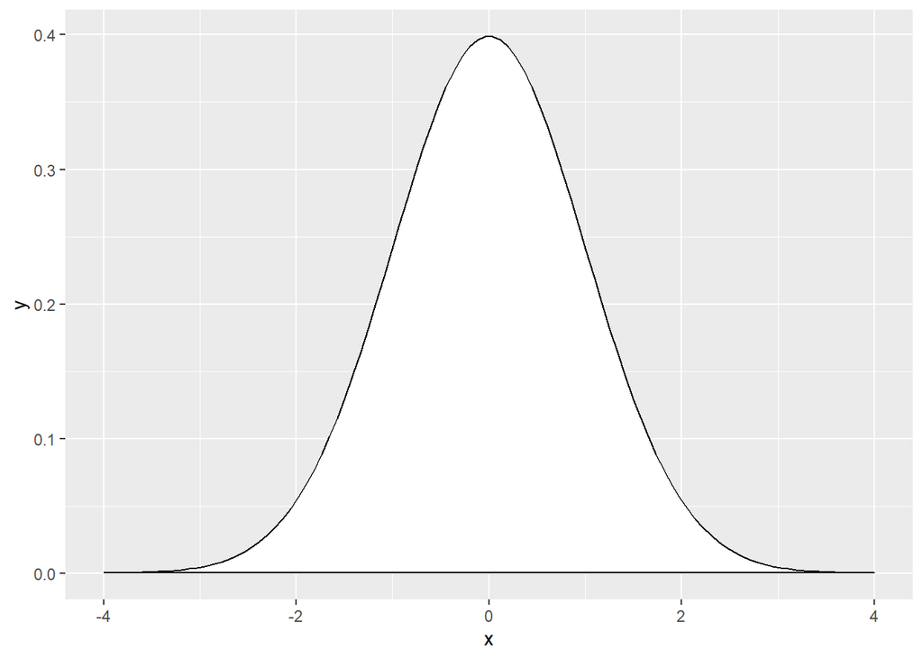

```r
x <- seq(-4, 4, length=100)
y <- dnorm(x)
data.frame(x, y) |>
  ggplot(aes(x, y)) +
    geom_polygon(fill="white", color="black") -> normal_curve
normal_curve
```

## P[Z < 1.5]

Use geom_vline and geom_label to draw a vertical reference line and add text to the normal curve. The pnorm function computes the standard normal probability.

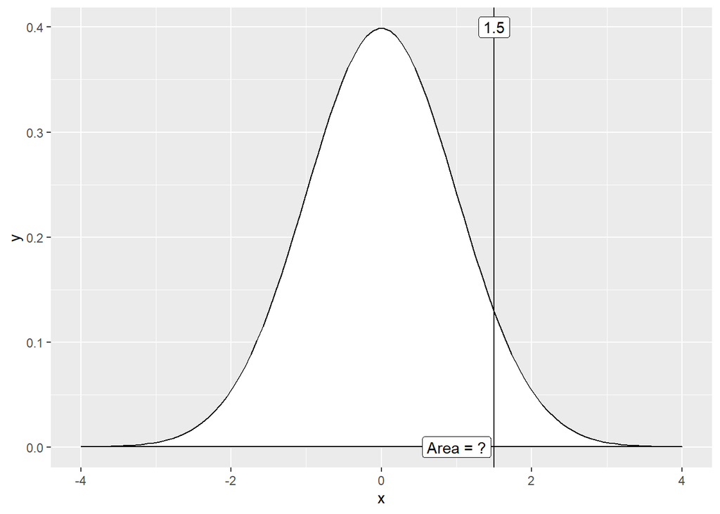

```r
a <- 1.5
normal_curve +
  geom_vline(xintercept=a) +
  geom_label(x=a, y=0.4, label=a) +
  geom_label(x=a-0.5, y=0, label="Area = ?")
```

```r
pnorm(1.5)
```

```
[1] 0.9331928
```

## P[Z < -0.5]

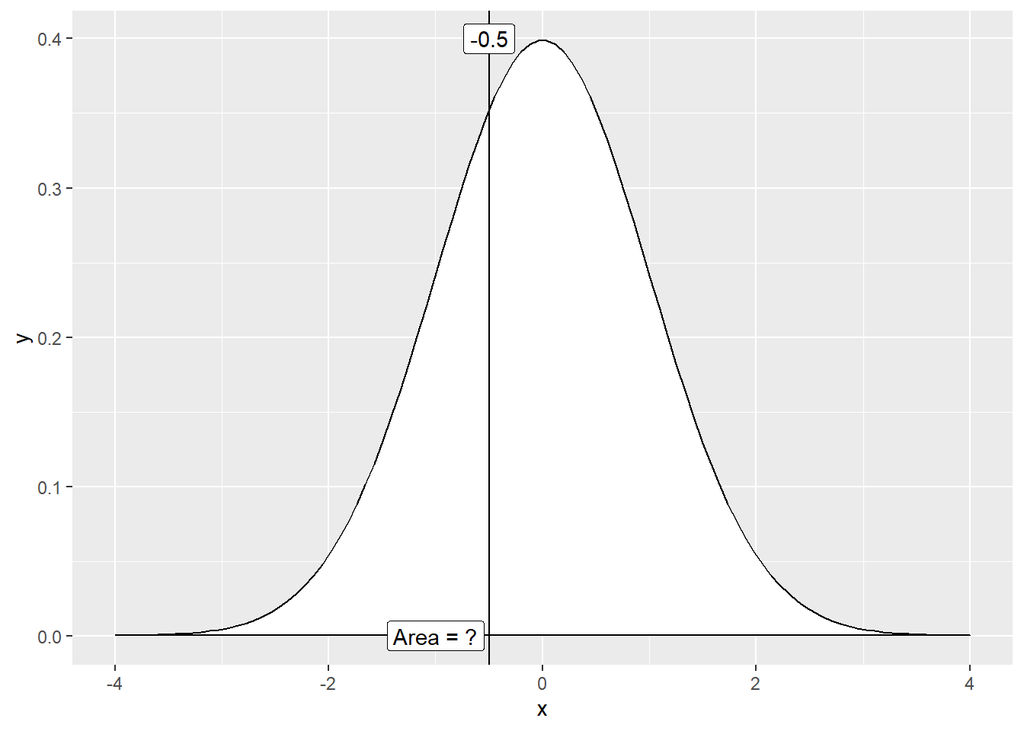

```r
a <- -0.5
normal_curve +
  geom_vline(xintercept=a) +
  geom_label(x=a, y=0.4, label=a) +
  geom_label(x=a-0.5, y=0, label="Area = ?")
```

```r
pnorm(-0.5)
```

```
[1] 0.3085375
```

## P[Z > 1]

When you are calculating the probability on the right (probability greater than some number), use 1-pnorm.

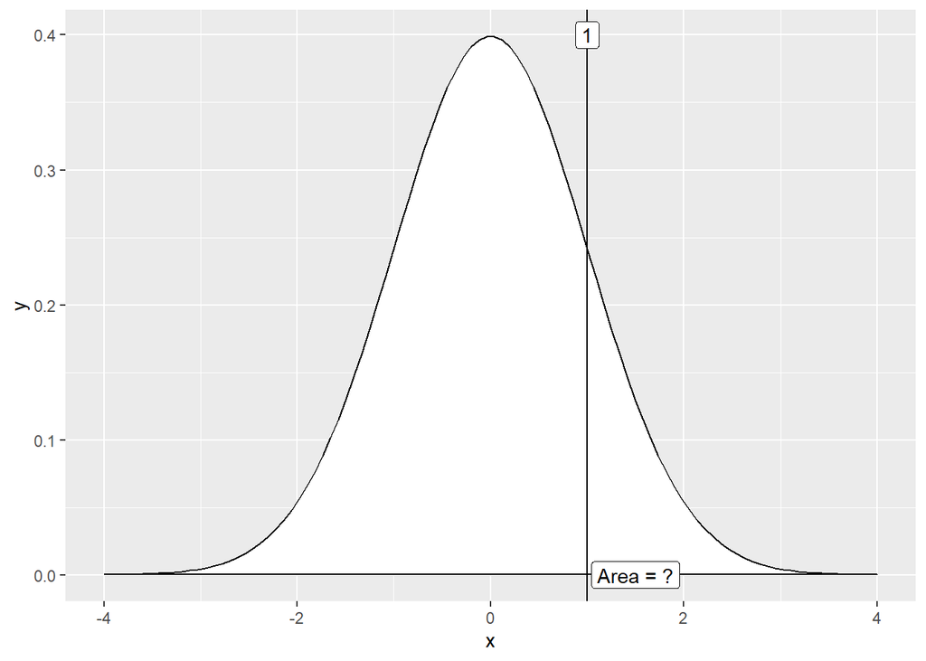

```r
a <- 1
normal_curve +
  geom_vline(xintercept=a) +
  geom_label(x=a, y=0.4, label=a) +
  geom_label(x=a+0.5, y=0, label="Area = ?")
```

```r
1- pnorm(1)
```

```
[1] 0.1586553
```

## P[Z > -2]

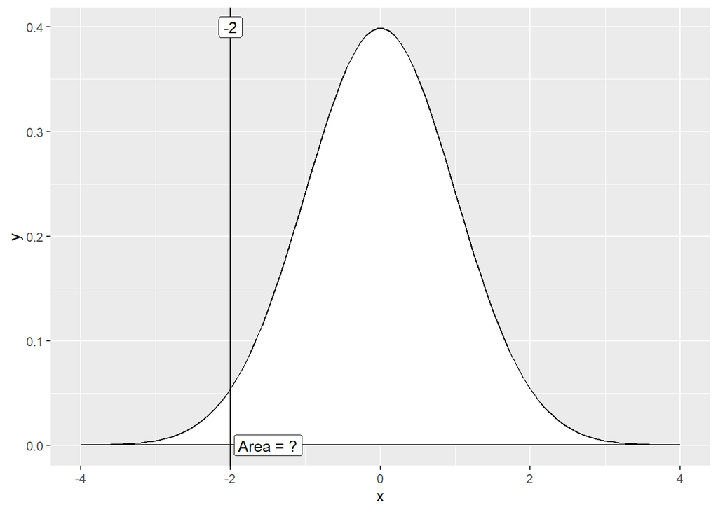

```r
a <- -2
normal_curve +
  geom_vline(xintercept=a) +
  geom_label(x=a, y=0.4, label=a) +
  geom_label(x=a+0.5, y=0, label="Area = ?")
```

```r
1- pnorm(-2)
```

```
[1] 0.9772499
```

## P[-2.5 < Z < 2.5]

When you are calculating the probability between two values, compute pnorm of the larger value minus pnorm of the smaller value.

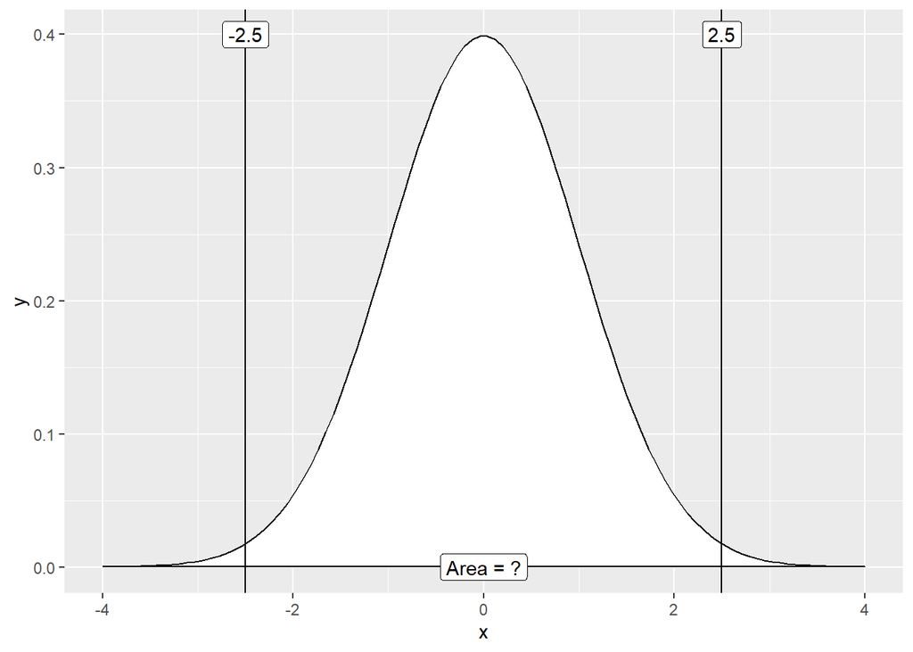

```r
a <- 2.5
normal_curve +
  geom_vline(xintercept=-a) +
  geom_vline(xintercept= a) +
  geom_label(x=-a, y=0.4, label=-a) +
  geom_label(x= a, y=0.4, label= a) +
  geom_label(x=0, y=0, label="Area = ?")
```

```r
pnorm(2.5)- pnorm(-2.5)
```

```
[1] 0.9875807
```

## P[-0.5 < Z < 0.5]

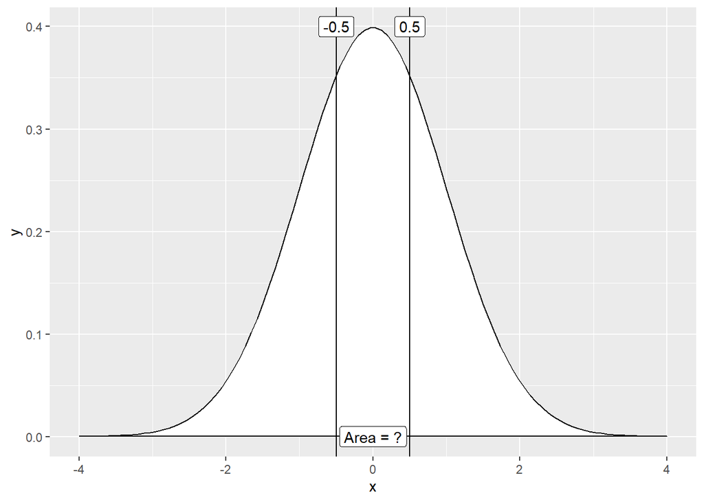

```r
a <- 0.5
normal_curve +
  geom_vline(xintercept=-a) +
  geom_vline(xintercept= a) +
  geom_label(x=-a, y=0.4, label=-a) +
  geom_label(x= a, y=0.4, label= a) +
  geom_label(x=0, y=0, label="Area = ?")
```

```r
pnorm(0.5) - pnorm(-0.5)
```

```
[1] 0.3829249
```

## P[-1 < z < 1]

Question 1

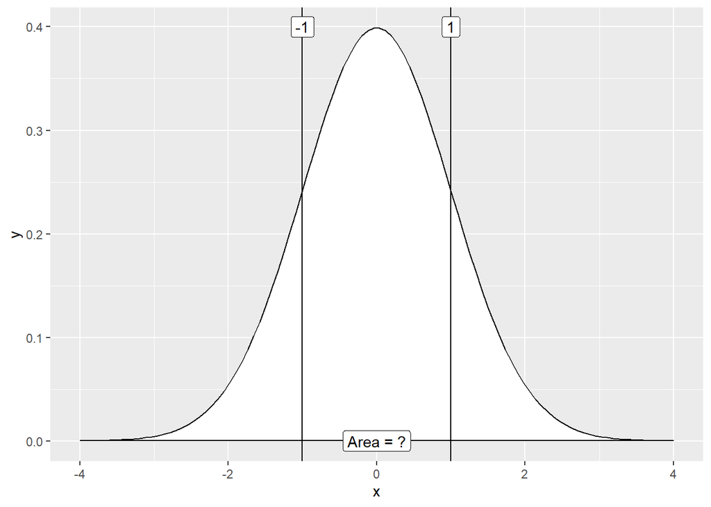

```r
a <- 1
normal_curve +
  geom_vline(xintercept=-a) +
  geom_vline(xintercept= a) +
  geom_label(x=-a, y=0.4, label=-a) +
  geom_label(x= a, y=0.4, label= a) +
  geom_label(x=0, y=0, label="Area = ?")
```

```r
pnorm(1) - pnorm(-1)
```

```
[1] 0.6826895
```

There is approximately 68.26% chance that the Z lies between -1 and 1 on the normal distribution curve.

## 25th percentile of a standard normal

Use qnorm to calculate quantiles of the standard normal distribution.

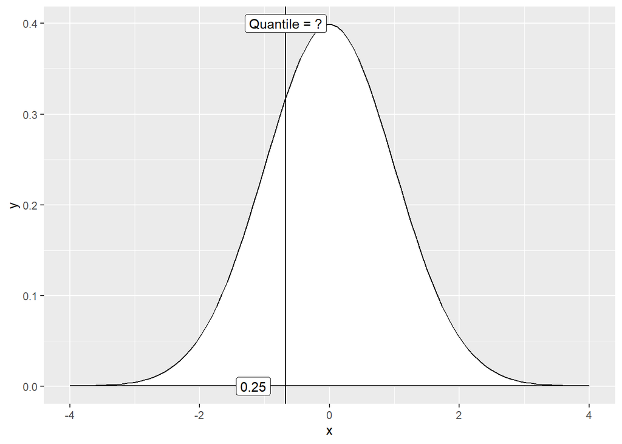

```r
p <- 0.25
a <- qnorm(p)
normal_curve +
  geom_vline(xintercept=a) +
  geom_label(x=a, y=0.4, label="Quantile = ?") +
  geom_label(x=a-0.5, y=0, label=p)
```

```r
qnorm(0.25)
```

```
[1] -0.6744898
```

## 90th percentile of a standard normal

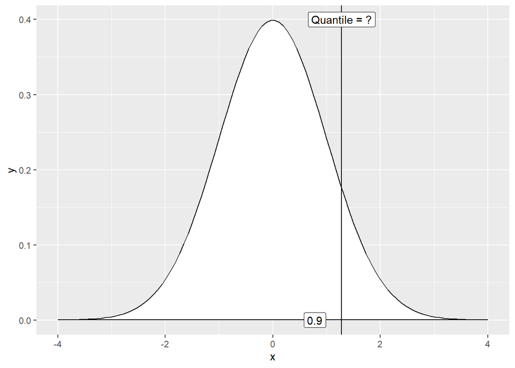

```r
p <- 0.9
a <- qnorm(p)
normal_curve +
  geom_vline(xintercept=a) +
  geom_label(x=a, y=0.4, label="Quantile = ?") +
  geom_label(x=a-0.5, y=0, label=p)
```

```r
qnorm(0.9)
```

```
[1] 1.281552
```

## 60th percentile of the standard normal

Question 2

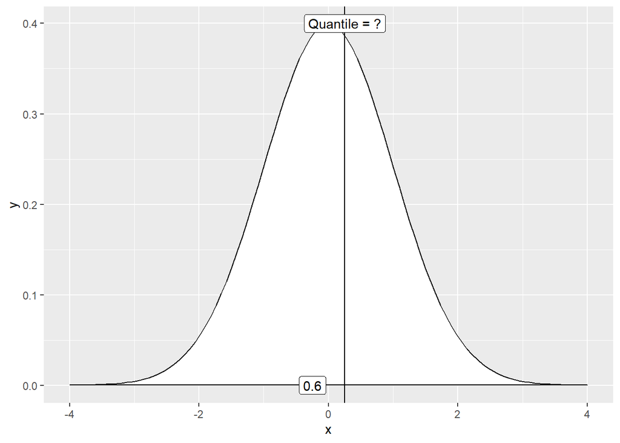

```r
p <- 0.6
a <- qnorm(p)
normal_curve +
  geom_vline(xintercept=a) +
  geom_label(x=a, y=0.4, label="Quantile = ?") +
  geom_label(x=a-0.5, y=0, label=p)
```

```r
qnorm(0.6)
```

```
[1] 0.2533471
```